# hw03-HIRATA

Ryo HIRATA

2014年10月20日

# 課題３

## 問題１

### Q1.階乗を計算する関数を作りなさい。

#### 1. 関数の名前を“fan_n”とし、引数をnと定義する。

#### 2. 戻り値は“result”とし、後にかけ算を行うため、“result”に“1”を割り当てる。

#### 3. nが負の値を取らないと仮定しているため、n<0の場合、計算しないように設定を行う。

#### 4. また、n=0の時、n!=1のため、この設定も行う。

```r
fan_n<- function(n){
                      #引数はnとする。
                      #戻り値はresultと置き、それを１と定義する。
  result<- 1

  #n<０の場合
       if(n<0){       #nが０より上の値を取る場合、以下の表示をさせる。
          print(nが０より上の値を取る)
          }

  #n=０の場合
  else if(n==0){      #n=0の場合、結果は１になるので、戻り値を1に設定する。
                return(1)
                }
  #n>0の場合
  else{
    for(i in n:1){     #n>0の場合、resultにある数nから1を掛けたものをresultとして指定する。
      result<- result*i
                 }
    return(result)
       }
}
```

#### 次に、確認のため、Rの内蔵関数(factorial)と自作の(fan_n)の結果を比較する。

```r
factorial(5)==fan_n(5)
```

```
## [1] TRUE
```

#### 結果についてTRUEであるので、自作の関数は内蔵関数と一致すると解釈できる。

## 問題2

### Q2.自分で作った階乗の関数を利用して、組み合わせを計算する関数を作りなさい。

#### 1. あるものをn個の中からk個を選ぶ組み合わせを計算するため、関数を“cho_n”と指定し、引数をn、kとする。

#### 2. nとkの関係について場合分けを行う。

```r
cho_n<- function(n,k){ #引数はnとkであり、戻り値はresultである。
  if(n<k){             #n個の中からk個を選ぶ組み合わせは存在しないので、０と定義する。
  return(0)            #resultを0として返す。
  }

  else{                #n>kの場合、組み合わせの関数は以下の通りになる。
    result<- fan_n(n)/(fan_n(k)*fan_n(n-k))
    return(result)     #resultを返す
  }
}
```

#### 次に、確認のため、Rの内蔵関数(choose)と自作のcho_nの結果を比較する。

```r
choose(8,2)==cho_n(8,2)
```

```
## [1] TRUE
```

## 問題３

### Q3.自分で作った組み合わせの関数を利用して、二項分布の確率質量を求める関数を作りなさい。

#### 1. 二項分布の確率質量を求める自作の関数を“db_n”とし、引数をx,n,pとする。

#### 2. 確率質量を求めるために計算を行う。その際、全問で自作した組み合わせ関数“cho_n”を利用する。

#### 3. 上記の結果をresultに定義し、戻り値として設定する。

```r
db_n<- function(x,n,p){ #引数はx,n,pであり、各々は成功回数、試行回数、成功確率を指す。
　　　　　　　　　　　　#確率質量の関数は以下の通り。
  result<- cho_n(n,x)*p^x*(1-p)^(n-x)

  return(result)        #戻り値はresultにし、それを返す。
}
```

#### 次に、確認のため、Rの内蔵関数(dbinom)と作成した“db_n”の結果を比較する。

```r
dbinom(2,100,0.7)==db_n(2,100,0.7) #x=2, n=100, p=0.7において、Rにある関数と上記の自作関数を比較。
```

```
## [1] FALSE
```

#### 結果として、内蔵関数と自作した関数の値は一致しなかった。念のため、個別的に検証する。

```r
dbinom(2,100,0.7) #既存の関数について、各々に先述の値を代入。
```

```
## [1] 1.388942e-48
```

```r
db_n(2,100,0.7)   #自作の関数について、各々に先述の値を代入。
```

```
## [1] 1.388942e-48
```

#### 小数点6位まで一致しており、それ以下の点で差が見られているだけであると推測できる。

## 問題4

### Q4. 自分で作った二項分布の関数を使い、nが2,3,5,10の場合について、確率質量を図示しなさい。pの値については任意とする。ただし、２つ以上のpで図を作りなさい。その際、for()ループを少なくとも1回使いなさい。

#### 1. 二項分布の確率質量を書き込むデータフレームを作成する。

#### 2. その際①init.data.frameと②lat.data.frameの２つを作成する。

```r
init.data.frame<- data.frame(p=NA, n=NA, x=NA, result=NA) #データフレーム①を作成。
lat.data.frame<- data.frame(p=NULL, n=NULL, x=NULL, result=NULL) #データフレーム②を作成。
```

#### p,n,x各々にfor()ループを用いる。

```r
for(p in c(0.3, 0.7)){      #p=0.5, 0.8と指定し、ループ。
  for(i in c(2, 3, 5, 10)){ #i= 2,3,5,10と指定し、ループ。
    for(j in 0:i){          #0からiまで、ループ。

   init.data.frame[1, ] <- c(paste("p=", p), paste("n=", i), j, db_n(j,i,p))
                            #for()内のp,i,jについて、p,n,xを代入する。

   lat.data.frame<- rbind (lat.data.frame, init.data.frame)
                            #rbindを用いて、2つのデータフレームをマージする。
   }
  }
}
```

#### これにより、先ほどのデータフレームが１つになった。

#### 念のため、データの中身について確認する。

```r
head(lat.data.frame) #出来上がったデータフレームについて、先頭から1行目を表示。
```

```
##        p    n x result
## 1 p= 0.3 n= 2 0   0.49
## 2 p= 0.3 n= 2 1   0.42
## 3 p= 0.3 n= 2 2   0.09
## 4 p= 0.3 n= 3 0  0.343
## 5 p= 0.3 n= 3 1  0.441
## 6 p= 0.3 n= 3 2  0.189
```

```r
tail(lat.data.frame) #データフレーム②の末尾から１行目を表示。
```

```
##         p     n  x       result
## 43 p= 0.7 n= 10  5 0.1029193452
## 44 p= 0.7 n= 10  6  0.200120949
## 45 p= 0.7 n= 10  7  0.266827932
## 46 p= 0.7 n= 10  8 0.2334744405
## 47 p= 0.7 n= 10  9  0.121060821
## 48 p= 0.7 n= 10 10 0.0282475249
```

```r
lat.data.frame$n<- factor(lat.data.frame$n,
                          levels= c("n= 2", "n= 3", "n= 5", "n= 10"))              #データフレーム内のnについての順列を問題に従って整理。
```

#### ggplotを用いて、成功確率毎のグラフを作成する。

#### 1. ggplot2を呼び出す。

#### 2. グラフを出力する際に、日本語の文字化けが起こることを防ぐため、フォントを指定する。

#### 3. 成功確率を分けてグラフを作成するため、同じデータフレームにおける異なる行のデータに分ける。

```r
require(ggplot2)                                                                      #gglpot2を呼び出す。
theme_set(theme_gray(base_size=12, base_family="HiraKakuProN-W3"))                    #フォントをヒラ角に指定。
prob4.bar1<- ggplot(data=lat.data.frame[1:24, ])                                      #1-24行目まで。
prob4.bar2<- ggplot(data=lat.data.frame[25:48, ])                                     #25-48行目まで。
```

#### p=0.3の場合の二項分布の確率質量を示す。

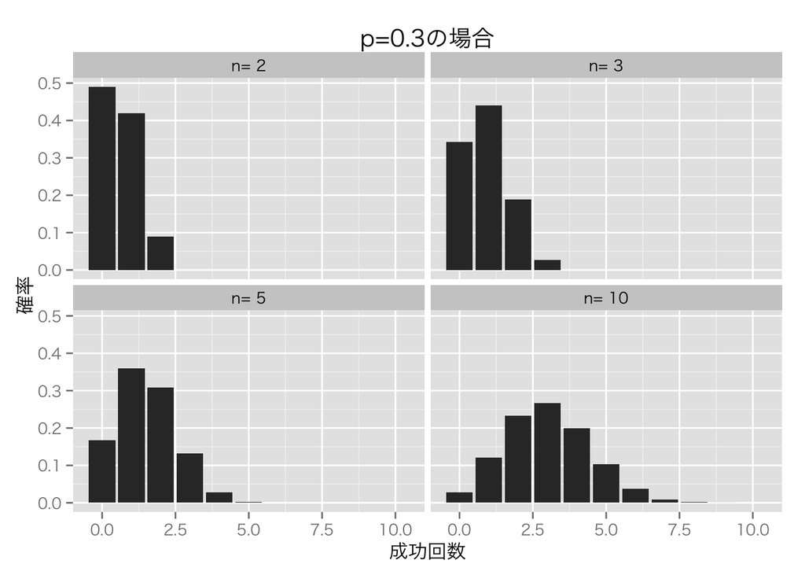

```r
prob4.bar1+geom_bar(aes(x= as.integer(x), y= as.numeric(result)), stat="identity") +
                    facet_wrap(~n)+ylab("確率")+xlab("成功回数")+ggtitle("p=0.3の場合")
```

#### p=0.7の場合の二項分布の確率質量を示す。

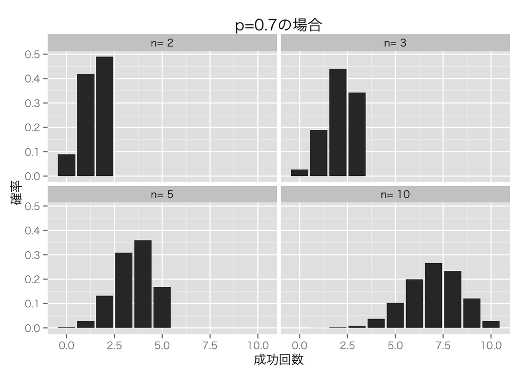

```r
prob4.bar2+ geom_bar (aes(x=as.integer(x), y=as.numeric(result)), stat="identity") +
                      facet_wrap(~n)+ylab("確率")+xlab("成功回数")+ggtitle("p=0.7の場合")
```